# Install Keras in R

This document lists the steps and resources to install keras in R. Before installing the keras, you need to know:

- Keras package was built within Tensorflow, and it is for training deep learning model.
- It is possible to install and run R/TensorFlow entirely from your own computer.
- Google provides TensorFlower for Windows, Mac and Linux.
- In order to run keras in R, you will need to install the latest version of Python.
- I recommend using the Anaconda release of Python.

### Step 1: Install anaconda

Download Anaconda from the following URL:

https://www.anaconda.com/python-3-7-package-build-out-miniconda-release/

You can download either python 2.7 or python 3.7.

[figure not shown]

If you have an older version of anaconda release of python, you can update your python with the following command in the terminal window:

```r
conda install python=3.7 anaconda=custom
```

### Step 2: Install Jupyter notebooks

Once Anaconda has been downloaded, you can install Jupyter notebooks using the following command in the terminal window:

```r
conda install jupyter
```

### Step 3: Install other python packages

You can also install some useful python packages in the terminal window.

```r
conda install scipy
pip install sklearn
pip install pandas
pip install matplotlib
pip install h5py
pip install tensorflow
pip install keras
```

### Step 4: Check installation

You can check if you have correctly installed the Keras and Tensorflow by the following command in the terminal window

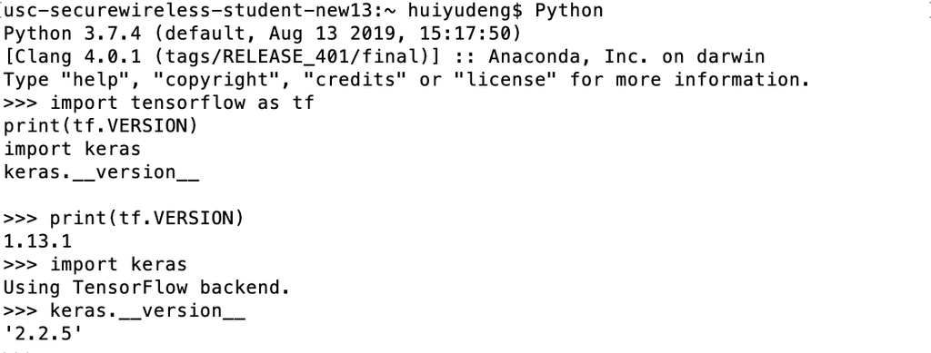

```r
python
import tensorflow as tf
print(tf.VERSION)
import keras
keras.__version__
```

### Step 5: Install keras in R

Now, you will be able to install the keras package in R!

```r
install.packages("Rcpp")
install.packages("devtools")
devtools::install_github("rstudio/reticulate", force=TRUE)
devtools::install_github("r-lib/processx")
devtools::install_github("rstudio/tensorflow")
devtools::install_github("rstudio/keras")
install_tensorflow(version="nightly")
```

Then, you can check if you have correctly installed the keras library in R by trying to load the mnist data from the keras package without any error messages.

```r
library(tensorflow)
library(processx)
library(keras)
mnist<-dataset_mnist()
```